# Implementation of the Moving Average Prices And Volatilities

Jerzy Pawlowski (jpawlowski@machinetrader.io)

06/17/2024

### Implementation of the Moving Average Prices and Volatilities

The Node-RED tab named *Tech Indicators* contains the implementations of various technical indicators in MachineTrader, including the moving average prices and volatilities.

The tab named *Tech Indicators* calculates the moving average prices and volatilities from live streaming stock prices for a single selected stock.

You can download the tab named *Tech Indicators* from the MachineTrader-Community repository on GitHub by clicking on this [**link**](https://drive.google.com/uc?export=download&id=1gOpD8O4JOah5xTCVcmQi4qNdmSVliTgr).

After you download the *JavaScript* file named *Tech_Indicators.json* to your computer, you should then install it in your MachineTrader instance, to create the tab named *Tech Indicators*.

The tab *Tech Indicators* receives the streaming stock prices from Alpaca, from the tab named *Alpaca Prices*, which is already included in your MachineTrader instance.  
The tab *Tech Indicators* also relies on the global variables produced by the tab named *Globals/Utilities*.

After you install the tab *Tech Indicators*, you must connect the *link-in node* to the left of the function node named *Get stock price*, to the *link-out node* called *Prices out* in the tab *Alpaca Prices*.

You can read more about the moving average prices and volatilities in [**this document**](https://algoquant.github.io/2024/06/17/Moving-Averages-Theory/).

You can also watch an instructional video about [**Calculating Moving Average Prices And Volatilities**](https://youtu.be/iAZMTEZeZDM) on the MachineTrader YouTube channel.

**Let’s take a look at the tab named *Tech Indicators*.**

The function node named *Initialize the parameters* creates flow variables needed for the calculations. It should be run once before the other nodes are run, by pressing the *inject* node on the left.

The multiple stock prices stream in from the tab *Alpaca Prices* into the node named *Get stock price*, through the small *link-in node* to its left. The function node *Get stock price* selects the prices only for the ticker in the tab variable *symboln*. The single stock prices then stream out through the small *link-out node* to its right, to the nodes which calculate the moving averages.

The dashed lines are the connectors for passing the live streaming stock prices to the function nodes.

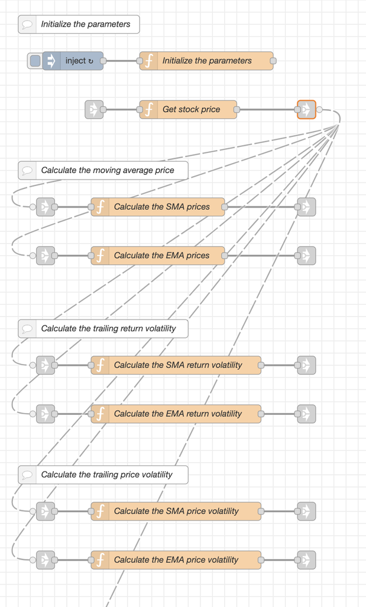

**The function node named *Initialize the parameters* creates the flow variables needed for the calculations:**

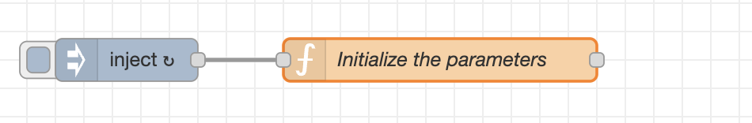

The function node named *Initialize the parameters* creates the following flow variables:

- symboln = the ticker string of the selected stock.
- lambdaf = the lambda decay factor which multiplies past estimates.
- volf = the volatility floor.
- pricec = the current stock price.
- pricep = the previous stock price, initially set to NaN.
- pricema = the moving average price, initially set to NaN.
- lb = the look-back window, i.e. the number of elements in the data queue.
- priceq = the data queue (buffer) for storing the recent stock prices.
- endpq = the position of the end of the price queue.
- retq = the data queue (buffer) for storing the recent stock returns.
- endrq = the position of the end of the returns queue.

**The data queue is used for calculating the simple moving averages of prices and volatilities.**

Below is an illustration of how an element is added to the data queue:

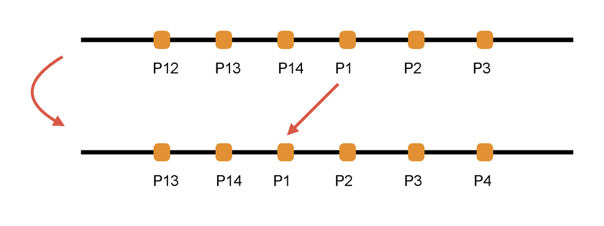

**The function node named *Get stock price* obtains the streaming prices for the ticker *symboln* from the tab named *Alpaca Prices*.**

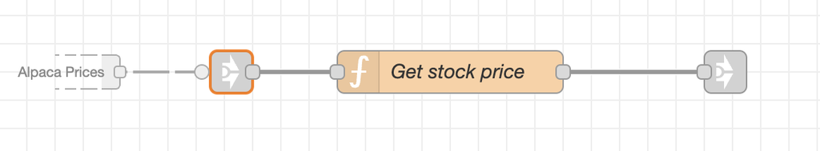

The prices for all the stocks stream from the tab *Alpaca Prices* into the small *link-in node* on the left.  
The function node *Get stock price* then extracts the prices only for the ticker *symboln*, and it passes them to the small *link-out node* on the right. The streaming stock prices from the *link-out node* can then be passed to the other nodes and strategy tabs.

For the live prices to stream, it’s necessary to download and install the tabs named *Alpaca Prices* and *Globals*. Then you must connect the *link-in node* to the left of the function node named *Get stock price* to the *link-out node* called *Prices out* in the tab *Alpaca Prices*.

**The function node named *Calculate the SMA prices* calculates the simple moving average prices.**

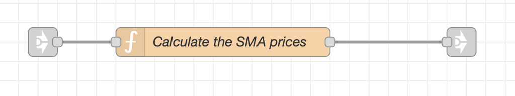

The stock prices flow from the node *Get stock price* into the small *link-in node* on the left. The function node *Calculate the SMA prices* then calculates the simple moving average prices, and it passes them to the small *link-out node* on the right. The streaming SMA prices from the *link-out node* can then be passed to the other nodes and strategy tabs.

**The function node named *Calculate the EMA prices* calculates the exponential moving average prices.**

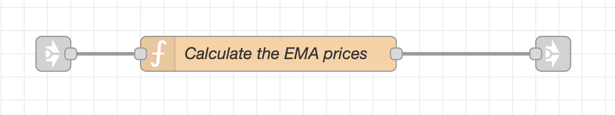

The stock prices flow from the node *Get stock price* into the small *link-in node* on the left. The function node *Calculate the EMA prices* then calculates the exponential moving average prices, and it passes them to the small *link-out node* on the right. The streaming EMA prices from the *link-out node* can then be passed to the other nodes and strategy tabs.

**The function node named *Calculate the SMA return volatility* calculates the simple moving average volatility of the stock returns.**

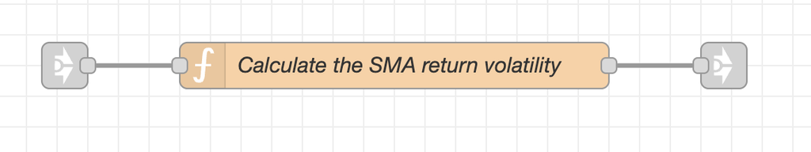

The stock prices flow from the node *Get stock price* into the small *link-in node* on the left. The function node *Calculate the SMA return volatility* then calculates the SMA return volatility, and it passes it to the small *link-out node* on the right. The streaming SMA return volatility from the *link-out node* can then be passed to the other nodes and strategy tabs.

**The function node named *Calculate the EMA return volatility* calculates the exponential moving average volatility of the stock returns.**

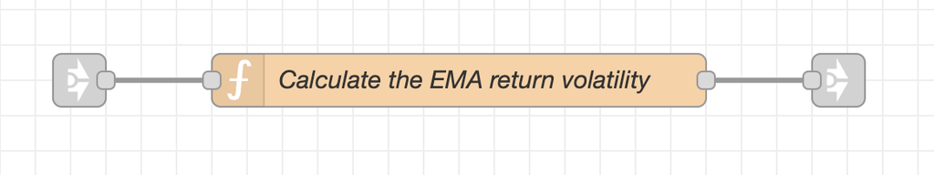

The stock prices flow from the node *Get stock price* into the small *link-in node* on the left. The function node *Calculate the EMA return volatility* then calculates the EMA return volatility, and it passes it to the small *link-out node* on the right. The streaming EMA return volatility from the *link-out node* can then be passed to the other nodes and strategy tabs.

**The function node named *Calculate the SMA price volatility* calculates the simple moving average volatility of the stock prices.**

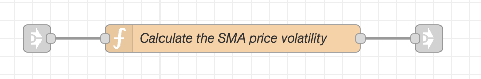

The stock prices flow from the node *Get stock price* into the small *link-in node* on the left. The function node *Calculate the SMA price volatility* then calculates the SMA price volatility, and it passes it to the small *link-out node* on the right. The streaming SMA price volatility from the *link-out node* can then be passed to the other nodes and strategy tabs.

**The function node named *Calculate the EMA price volatility* calculates the exponential moving average volatility of the stock prices.**

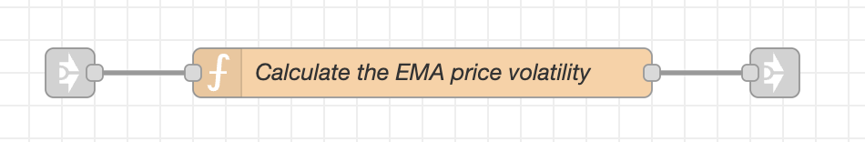

The stock prices flow from the node *Get stock price* into the small *link-in node* on the left. The function node *Calculate the EMA price volatility* then calculates the EMA price volatility, and it passes it to the small *link-out node* on the right. The streaming EMA price volatility from the *link-out node* can then be passed to the other nodes and strategy tabs.